# Neurodiversity Is a Competitive Advantage

Hi,

[Marginalized groups](https://hbr.org/topic/subject/marginalized-groups)

# Neurodiversity as a Competitive Advantage

Why you should embrace it in your workforce

by

- [Robert D. Austin](https://hbr.org/search?term=robert%20d.%20austin)

and

- [Gary P. Pisano](https://hbr.org/search?term=gary%20p.%20pisano)

[From the Magazine (May–June 2017)](https://hbr.org/archive-toc/BR1703) · Long read

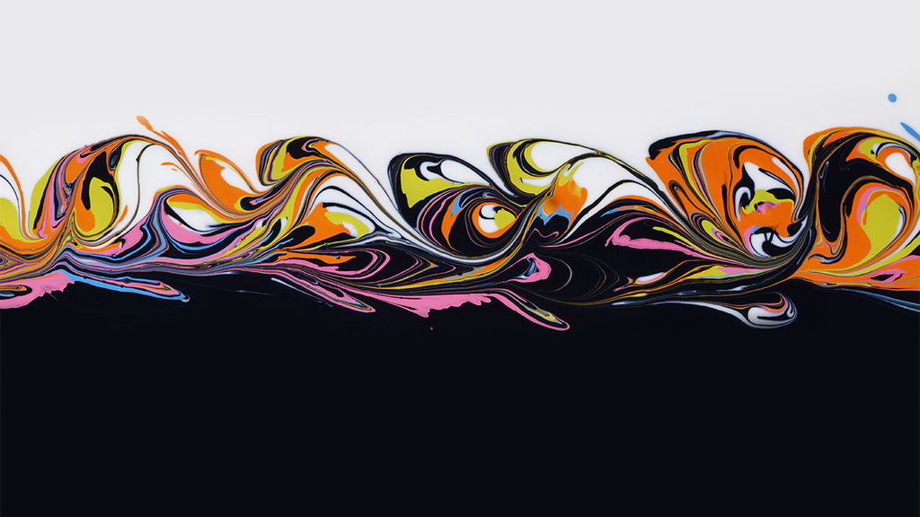

Paul Taylor/Getty Images

Summary.

Many people with neurological conditions such as autism spectrum disorder and dyslexia have extraordinary skills, including in pattern recognition, memory, and mathematics. Yet they often struggle to fit the profiles sought by employers.

A growing number of companies, including SAP, Hewlett-Packard Enterprise, and Microsoft, have reformed their HR processes in order to access neurodiverse talent—and are seeing productivity gains, quality improvement, boosts in innovative capabilities, and increased employee engagement as a result. The programs vary but have seven major elements in common. Companies should:

- Team with governments or nonprofits experienced in working with people with disabilities
- Use noninterview assessment processes
- Train other workers and managers in what to expect
- Set up a support system
- Tailor methods for managing careers
- Scale the program
- Mainstream the program

The work for managers will be harder, but the payoff to companies will be considerable: access to more of their employees’ talents, along with diverse perspectives that will help them compete.

Meet John. He’s a wizard at data analytics. His combination of mathematical ability and software development skill is highly unusual. His CV features two master’s degrees, both with honors. An obvious guy for a tech company to scoop up, right?

Until recently, no. Before John ran across a firm that had begun experimenting with alternative approaches to talent, he was unemployed for more than two years. Other companies he had talked with badly needed the skills he possessed. But he couldn’t make it through the hiring process.

If you watched John for a while, you’d start to see why. He seems, well, different. He wears headphones all the time, and when people talk to him, he doesn’t look right at them. He leans over every 10 minutes or so to tighten his shoelaces; he can’t concentrate when they’re loose. When they’re tight, though, John is the department’s most productive employee. He is hardworking and never wants to take breaks. Although his assigned workplace “buddy” has finally persuaded him to do so, he doesn’t enjoy them.

“John” is a composite of people whose privacy we wanted to protect—people with autism spectrum disorder. He is representative of participants in the programs of pioneering companies that have begun seeking out “neurodiverse” talent.

A lot of people are like John. The incidence of autism in the United States is now 1 in 42 among boys and 1 in 189 among girls, according to the Centers for Disease Control and Prevention. And although corporate programs have so far focused primarily on autistic people, it should be possible to extend them to people affected by dyspraxia (a neurologically based physical disorder), dyslexia, ADHD, social anxiety disorders, and other conditions. Many people with these disorders have higher-than-average abilities; research shows that some conditions, including autism and dyslexia, can bestow special skills in pattern recognition, memory, or mathematics. Yet those affected often struggle to fit the profiles sought by prospective employers.

Neurodiverse people frequently need workplace accommodations, such as headphones to prevent auditory overstimulation, to activate or maximally leverage their abilities. Sometimes they exhibit challenging eccentricities. In many cases the accommodations and challenges are manageable and the potential returns are great. But to realize the benefits, most companies would have to adjust their recruitment, selection, and career development policies to reflect a broader definition of talent.

A growing number of prominent companies have reformed their HR processes in order to access neurodiverse talent; among them are SAP, Hewlett Packard Enterprise (HPE), Microsoft, Willis Towers Watson, Ford, and EY. Many others, including Caterpillar, Dell Technologies, Deloitte, IBM, JPMorgan Chase, and UBS, have start-up or exploratory efforts under way. We have had extensive access to the neurodiversity programs at SAP, HPE, and Specialisterne (the Danish consulting company that originated such programs) and have also interacted with people at Microsoft, Willis Towers Watson, and EY.

Although the programs are still in early days—SAP’s, the longest running among major companies, is just four years old—managers say they are already paying off in ways far beyond reputational enhancement. Those ways include productivity gains, quality improvement, boosts in innovative capabilities, and broad increases in employee engagement. Nick Wilson, the managing director of HPE South Pacific—an organization with one of the largest such programs—says that no other initiative in his company delivers benefits at so many levels.

Perhaps the most surprising benefit is that managers have begun thinking more deeply about leveraging the talents of *all* employees through greater sensitivity to individual needs. SAP’s program “forces you to get to know the person better, so you know how to manage them,” says Silvio Bessa, the senior vice president of digital business services. “It’s made me a better manager, without a doubt.”

## Why Neurodiversity Presents Opportunities

“Neurodiversity is the idea that neurological differences like autism and ADHD are the result of normal, natural variation in the human genome,” John Elder Robison, a scholar in residence and a cochair of the Neurodiversity Working Group at the College of William & Mary, writes [in a blog](https://www.psychologytoday.com/blog/my-life-aspergers/201310/what-is-neurodiversity) on Psychology Today’s website. Robison, who himself has Asperger’s syndrome, adds, “Indeed, many individuals who embrace the concept of neurodiversity believe that people with differences do not need to be cured; they need help and accommodation instead.” We couldn’t agree more.

Everyone is to some extent *differently abled* (an expression favored by many neurodiverse people), because we are all born different and raised differently. Our ways of thinking result from both our inherent “machinery” and the experiences that have “programmed” us.

Most managers are familiar with the advantages organizations can gain from diversity in the backgrounds, disciplinary training, gender, culture, and other individual qualities of employees. Benefits from neurodiversity are similar but more direct. Because neurodiverse people are wired differently from “neurotypical” people, they may bring new perspectives to a company’s efforts to create or recognize value. At HPE, neurodiverse software testers observed that one client’s projects always seemed to go into crisis mode before a launch. Intolerant of disorder, they strenuously questioned the company’s apparent acceptance of the chaos. This led the client company to realize that it had indeed become too tolerant of these crises and, with the help of the testers, to successfully redesign the launch process. At SAP, a neurodiverse customer-support analyst spotted an opportunity to let customers help solve a common problem themselves; thousands of them subsequently used the resources he created.

Nevertheless, the neurodiverse population remains a largely untapped talent pool. Unemployment runs as high as 80% (this figure includes people with more-severe disorders, who are not candidates for neurodiversity programs). When they are working, even highly capable neurodiverse people are often underemployed. Program participants told us story after story of how, despite having solid credentials, they had previously had to settle for the kinds of jobs many people leave behind in high school. When SAP began its Autism at Work program, applicants included people with master’s degrees in electrical engineering, biostatistics, economic statistics, and anthropology and bachelor’s degrees in computer science, applied and computational mathematics, electrical engineering, and engineering physics. Some had dual degrees. Many had earned very high grades and graduated with honors or other distinctions. One held a patent.

Not surprisingly, when autistic people with those sorts of credentials do manage to get hired, many turn out to be capable, and some are really great. Over the past two years HPE’s program has placed more than 30 participants in software-testing roles at Australia’s Department of Human Services (DHS). Preliminary results suggest that the organization’s neurodiverse testing teams are 30% more productive than the others.

Inspired by the successes at DHS, the Australian Defense Department is now working with HPE to develop a neurodiversity program in cybersecurity; participants will apply their superior pattern-detection abilities to tasks such as examining logs and other sources of messy data for signs of intrusion or attack. Using assessment methods borrowed from the Israeli Defense Forces (IDF), it has found candidates whose relevant abilities are “off the charts.” (The IDF’s Special Intelligence Unit 9900, which is responsible for analyzing aerial and satellite imagery, has a group staffed primarily with people on the autism spectrum. It has proved that they can spot patterns others do not see.)

The case for neurodiverse hiring is especially compelling given the skills shortages that increasingly afflict technology and other industries. For example, the European Union faces a shortage of 800,000 IT workers by 2020, according to a European Commission study. The biggest deficits are expected to be in strategically important and rapidly expanding areas such as data analytics and IT services implementation, whose tasks are a good match with the abilities of some neurodiverse people.

## Why Companies Don’t Tap Neurodiverse Talent

What has kept so many companies from taking on people with the skills they badly need? It comes down to the way they find and recruit talent and decide whom to hire (and promote).

Especially in large companies, HR processes are developed with an eye toward wide application across the organization. But there is a conflict between scalability and the goal of acquiring neurodiverse talent. “SAP focuses on having scalable HR processes; however, if we were to use the same processes for everyone, we would miss people with autism,” says Anka Wittenberg, the company’s chief diversity and inclusion officer.

In addition, the behaviors of many neurodiverse people run counter to common notions of what makes a good employee—solid communication skills, being a team player, emotional intelligence, persuasiveness, salesperson-type personalities, the ability to network, the ability to conform to standard practices without special accommodations, and so on. These criteria systematically screen out neurodiverse people.

But they are not the only way to provide value. In fact, in recent decades the ability to compete on the basis of *innovation* has become more crucial for many companies. Innovation calls on firms to add variety to the mix—to include people and ideas from “the edges,” as SAP put it in the press release announcing its program. Having people who see things differently and who maybe don’t fit in seamlessly “helps offset our tendency, as a big company, to all look in the same direction,” Bessa says.

You might think that organizations could simply seek more variety in prospective employees while retaining their traditional recruiting, hiring, and development practices. Many have taken that approach: Their managers still work top down from strategies to capabilities needed, translating those into organizational roles, job descriptions, and recruiting checklists. But two big problems cause them to miss neurodiverse talent.

The first involves a practice that is almost universal under the traditional approach: interviewing. Although neurodiverse people may excel in important areas, many don’t interview well. For example, autistic people often don’t make good eye contact, are prone to conversational tangents, and can be overly honest about their weaknesses. Some have confidence problems arising from difficulties they experienced in previous interview situations. Neurodiverse people more broadly are unlikely to earn higher scores in interviews than less-talented neurotypical candidates. SAP and HPE have found that it can take weeks or months to discover how good some program participants are (or, equally important, where their limitations lie). Fortunately, as we’ll see, interviews are not the only way to assess a candidate’s suitability.

The second problem, especially common in large companies, derives from the assumption that scalable processes require absolute conformity to standardized approaches. As mentioned, employees in neurodiversity programs typically need to be allowed to deviate from established practices. This shifts a manager’s orientation from assuring compliance through standardization to adjusting individual work contexts. Most accommodations, such as installing different lighting and providing noise-canceling headphones, are not very expensive. But they do require managers to tailor individual work settings more than they otherwise might.

## How Pioneers Are Changing The Talent Management Game

The tech industry has a history of hiring oddballs. The talented nerd who lacks social graces has become a cultural icon, as much a part of the industry mythos as the company that starts in a garage. In his book NeuroTribes, Steve Silberman points out that the incidence of autism is particularly high in places like Silicon Valley (for reasons not completely understood). He and others have hypothesized that many of the industry’s “oddballs” and “nerds” might well have been “on the spectrum,” although undiagnosed. Hiring for neurodiversity, then, could be seen as an extension of the tendencies of a culture that recognizes the value of nerds.

In recent years a few pioneering companies have formalized and professionalized those tendencies. Although their programs vary, they have elements in common, not least because they draw on the body of knowledge developed at Specialisterne. Thorkil Sonne founded the firm in 2004, motivated by the autism diagnosis of his third child. Over the next several years it developed and refined noninterview methods for assessing, training, and managing neurodiverse talent and demonstrated the viability of its model by running a successful for-profit company focused on software testing.

Innovation calls on firms to include people and ideas “from the edges.”

Dissatisfied with the rate at which his own company could create jobs, Sonne established the Specialist People Foundation (recently renamed the Specialisterne Foundation) in 2008 to spread his company’s know-how to others and persuade multinationals to start neurodiversity programs. Most companies that have done so have worked with the foundation to deploy some version of the Specialisterne approach. It has seven major elements:

### Team with “social partners” for expertise you lack.

Managers in, say, a tech company know a lot about many things but usually are not experts in autism or other categories of neurodiversity. Also, for many good reasons, companies hesitate to extend their activities into employees’ private lives, where neurodiverse people may need extra help.

To fill these gaps, the companies we studied entered into relationships with “social partners”—government or nonprofit organizations committed to helping people with disabilities obtain jobs. SAP has worked with California’s Department of Rehabilitation, Pennsylvania’s Office of Vocational Rehabilitation, the U.S. nonprofits EXPANDability and the Arc, and overseas agencies such as EnAble India, while HPE has worked with Autism SA (South Australia). Such groups help companies navigate local employment regulations that apply to people with disabilities, suggest candidates from lists of neurodiverse people seeking employment, assist in prescreening, help arrange public funding for training, sometimes administer training, and provide the mentorship and ongoing support (especially outside work hours) needed to ensure that neurodiverse employees will succeed. In Germany, recognition of the benefits of moving people off public assistance and into jobs that generate tax revenue has led to publicly funded positions to support the retention of neurodiverse employees. Although estimates of the benefits a government gains by turning such people into tax-paying tech workers vary, they often are on the order of $50,000 per person a year.

### Use nontraditional, noninterview-based assessment and training processes.

To this end, Specialisterne created “hangouts”—comfortable gatherings, usually lasting half a day, in which neurodiverse job candidates can demonstrate their abilities in casual interactions with company managers. At the end of a hangout, some candidates are selected for two to six weeks of further assessment and training (the duration varies by company). During this time they use Lego Mindstorms robotic construction and programming kits to work on assigned projects—first individually and then in groups, with the projects becoming more like actual work as the process continues. Some companies have additional sessions. SAP, for example, established a “soft skills” module to help candidates who have never worked in a professional environment become familiar with the norms of such a setting. These efforts are typically funded by the government or nonprofits. Trainees are usually paid.

Despite the social difficulties experienced by many neurodiverse people, candidates often display complex collaborative and support behaviors during the project-based assessment period. At HPE, for example, groups were asked to devise a reliable robotic pill-dispensing system. During the presentation of solutions, one candidate froze. “I’m sorry, I can’t do it,” he said. “The words are all jumbled up in my head.” His neurodiverse teammates rushed to his rescue, surrounding and reassuring him, and he was able to finish.

By extending the assessment process, such programs allow time for candidates’ capabilities to surface. There are, of course, other ways to do this. HPE has begun using internships that include similar elements.

### Train other workers and managers.

Short (some are just half a day), low-key training sessions help existing employees understand what to expect from their new colleagues—for example, that they might need accommodations and might seem different. Managers get somewhat more-extensive training to familiarize them with sources of support for program employees.

### Set up a support ecosystem.

Companies with neurodiverse programs design and maintain simple support systems for their new employees. SAP defines two “support circles”—one for the workplace, the other for an employee’s personal life. The workplace support circle includes a team manager, a team buddy, a job and life skills coach, a work mentor, and an “HR business partner,” who oversees a group of program participants. Buddies are staff members on the same team who provide assistance with daily tasks, workload management, and prioritization. Job and life skills coaches are usually from social partner organizations. Other social partner roles include vocational rehab counselor and personal counselor. Usually, families of employees also provide support.

HPE takes a different approach. It places new neurodiverse employees in “pods” of about 15 people, where they work alongside neurotypical colleagues in a roughly 4:1 ratio while two managers and a consultant are tasked with addressing neurodiversity-related issues.

### Tailor methods for managing careers.

Employees hired through these programs need long-term career paths, just as other workers do. This requires serious thought about ongoing assessment and development that will take the special circumstances of neurodiverse employment into account. Fortunately, over time supervisors usually get a good sense of program employees’ talents and limitations. Participants undergo the same performance evaluations that other employees do, but managers work within those processes to set specific goals. Although some goals may relate to participants’ conditions, no allowances are made for unsatisfactory performance. If anything, neurodiverse employees must satisfy *more* requirements than others, because they must meet program objectives in addition to the performance objectives expected of anyone in their role.

Some participants quickly demonstrate potential to become integrated into the mainstream organization and go further in their careers. HPE’s pods are designed to provide a safe environment in which participants can build skills that will allow them to perform well and eventually to transition out of their pods into more-mainstream jobs.

Employee engagement has risen in areas that neurodiversity programs touch.

### Scale the program.

SAP has announced an intention to make 1% of its workforce neurodiverse by 2020—a number chosen because it roughly corresponds to the percentage of autistic people in the general population. Microsoft, HPE, and others are also working to enlarge their programs, although they have declined to set numerical targets. It’s easiest to expand employment in those areas, such as software testing, business analytics, and cybersecurity, in which tasks are a good fit with neurodiverse talent. SAP, however, has placed its more than 100 program employees in 18 roles. “The original expectation, as I understood it, was that these colleagues would be mostly focused on repetitive work, such as software testing,” one manager told us. “But in practice they have been able to add value in a much broader range of tasks.” Those include product management, which involves coordinating the development of new SAP offerings; HR service associate, which entails organizing and planning HR activities; associate consultant, which requires helping customers apply SAP solutions to business problems; and customer support, which means working with customers on the phone to help them use SAP software. The latter two defy the assumption that people with autism can’t hold jobs that require social skills.

### Mainstream the program.

The success of neurodiversity programs has prompted some companies to think about how ordinary HR processes may be excluding high-quality talent. SAP is conducting a review to determine how recruiting, hiring, and development could take a broader view. Its stated goal is to make its mainstream talent processes so “neurodiversity friendly” that it can ultimately close its neurodiversity program. Microsoft has similar ambitions.

Companies have experienced a surprising array of benefits from neurodiversity programs. Some are straightforward: Firms have become more successful at finding and hiring good and even great talent in tough-to-fill skills categories. Products, services, and bottom lines have profited from lower defect rates and higher productivity. Both SAP and HPE report examples of neurodiverse employees’ participating on teams that generated significant innovations (one, at SAP, helped develop a technical fix worth an estimated $40 million in savings).

Other benefits are subtler. One executive told us that efforts to make corporate communications more direct, in order to account for the difficulties autistic employees have with nuance, irony, and other fine points of language, have improved communication overall. The perfectionist tendencies of some HPE software-testing pods have caused client organizations to raise their game and stop viewing certain common problems as inevitable. In addition, employee engagement has risen in areas the programs touch: Neurotypical people report that involvement makes their work more meaningful and their morale higher. And early indications suggest that program employees, appreciative of having been given a chance, are very loyal and have low rates of turnover.

Last but not least, the programs confer reputational benefits. The companies that pioneered them have been recognized by the United Nations as exemplars of responsible management and have won global corporate citizenship awards.

## Challenges of a Neurodiverse Workforce

To be sure, companies implementing neurodiversity programs have encountered challenges. Although there are plenty of potential candidates, many are hard to identify, because universities—sensitive to issues of discrimination—do not classify students in neurodiversity terms, and potential candidates do not necessarily self-identify. In response, HPE is helping colleges and high schools set up nontraditional “work experience” programs for neurodiverse populations. These involve video gaming, robotic programming, and other activities. Microsoft, too, is working with universities to improve methods of identifying and accessing neurodiverse talent.

Another common difficulty involves the dashed hopes of candidates who are not chosen for placement—an inevitable circumstance that must be handled carefully. At one company, parents whose son did not qualify for a job wrote to the CEO; the program had raised their hopes that he would finally achieve meaningful employment, and they were understandably disappointed. Executives fretted about a potential PR problem. In the end, compassionate discussions between the parents and managers of the program—some of whom had families that had experienced similar issues—calmed the situation.

Issues related to fairness and norms of interaction might arise as well. In one case we encountered, a program participant who had overstimulation difficulties was given his own office while four people in a nearby department were crowded into a similar space, generating complaints. Those subsided after an explanation was offered. We also heard of instances in which the excessive honesty typical of autistic people raised hackles. One concerned a program employee who told a colleague, “You stink at your job.” Coaching by managers and mentors can help address such situations.

Some supervisors reported that the program generated extra work for them. For instance, the perfectionist tendencies of some participants made it difficult for those employees to judge which defects were worth fixing, which were not, and which required them to seek additional direction.

Managing neurodiverse employees’ stress presents another challenge. We heard reports that unexpected and uncontrollable events, such as systems outages that interfered with work routines, caused unusually high levels of anxiety among participants. Many people we interviewed emphasized the need to be sensitive to program employees’ stress. To keep it under control, some participants work only part-time—a limitation that may create problems, especially when deadlines loom.

To handle such situations, organizations need people in place who can spot and address issues before they escalate. Many managers said that with these and other supports, they could perform their jobs in a fairly normal fashion. And contrary to their initial assumptions, SAP managers found they could even supervise program participants remotely, as long as buddies and mentors provided support locally.

## A Major Shift in Managing People

Neurodiversity programs induce companies and their leaders to adopt a style of management that emphasizes placing each person in a context that maximizes her or his contributions.

SAP uses a metaphor to communicate this idea across the organization: People are like puzzle pieces, irregularly shaped. Historically, companies have asked employees to trim away their irregularities, because it’s easier to fit people together if they are all perfect rectangles. But that requires employees to leave their differences at home—differences firms need in order to innovate. “The corporate world has mostly missed out on this [benefit],” Anka Wittenberg observes.

This suggests that companies must embrace an alternative philosophy, one that calls on managers to do the hard work of fitting irregular puzzle pieces together—to treat people not as containers of fungible human resources but as unique individual assets. The work for managers will be harder. But the payoff for companies will be considerable: access to more of their employees’ talents along with diverse perspectives that may help them compete more effectively. “Innovation,” Wittenberg notes, “is most likely to come from parts of us that we don’t all share.”

A version of this article appeared in the [May–June 2017](https://hbr.org/archive-toc/BR1703) issue (pp.96–103) of *Harvard Business Review*.

Read more on [**Marginalized groups**](https://hbr.org/topic/subject/marginalized-groups?ab=articlepage-topic) or related topics [**Neurodiversity**](https://hbr.org/topic/subject/neurodiversity?ab=articlepage-topic), [**Managing people**](https://hbr.org/topic/subject/managing-people?ab=articlepage-topic) and [**Developing employees**](https://hbr.org/topic/subject/developing-employees?ab=articlepage-topic)

For HBR Subscribers

Must Reads on Diversity

[figure not shown]